# Exercise_01_BC

Betsy Cowdery

September 8, 2014

1. Evaluate the following:
1. ln(1)
2. ln(0)
3. ln(e)
4. ln(-5)
5. -ln(5)
6. ln(1/5)

```r
fcn = c("ln(1) = ", "ln(0) = ", "ln(e) = ", "ln(-5) = ","-ln(5) = ","ln(1/5))) = ")
value = c(log(1),log(0),log(exp(1)),log(-5),-log(5),log(1/5))
```

```
## Warning: NaNs produced
```

```r
data.frame(fcn,value)
```

```
##            fcn  value
## 1     ln(1) =   0.000
## 2     ln(0) =    -Inf
## 3     ln(e) =   1.000
## 4    ln(-5) =     NaN
## 5    -ln(5) =  -1.609
## 6 ln(1/5))) =  -1.609
```

7. How does R represent when the output of a function is not a number?  
   Error message : “Warning message: In log(-5) : NaNs produced”
   - in other words, function will return a NaN
2. Why are we multiplying the results of the atan and atan2 functions by 180/pi?  
   To convert from radians into degrees.
3. How is the atan2 function different from the atan function?  
   `atan2(y, x) == atan(y/x)`
4. What is the difference between log and log10?  
   `log()` performs log base e and `log10()` performs log base 10
5. Given a right triangle with sides x = 5 and y = 13, calculate the length of the hypotenuse (show code)

```r
x<-5; y<-13
sqrt(x^2+y^2)
```

```
## [1] 13.93
```

6. If a population starts with a density of 5 individuals/hectare and grows exponentially at a growth rate r=0.04/year, what is the size of the population in n years? (show code)

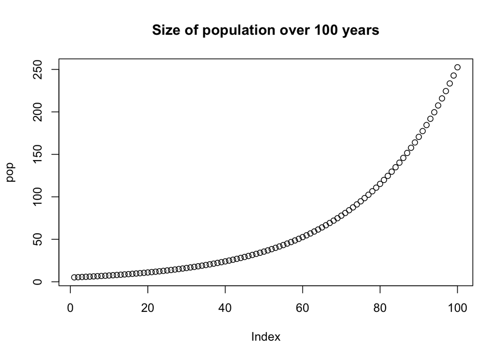

```r
r <- .04 # growth rate
pop <- c()
for(n in 1:100){pop <- c(pop,5*(1+r)^n)} # look at years n = 1 though 100
plot(pop, main = "Size of population over 100 years")
```

7. Subtract the month you were born from the remainder left after you divide the year you were born by the day you were born (show code)

```r
day   <- 26
month <- 9
year  <- 1987
(year/day)-month
```

```
## [1] 67.42
```

8. Describe the difference in output between sum and cumsum. `cumsum` give the iterative summation through the array. `sum` gives the sum of all elements in the arry (ie the last value in cumsum)

```r
x <- 1:10
sum(x)
```

```
## [1] 55
```

```r
cumsum(x)
```

```
##  [1]  1  3  6 10 15 21 28 36 45 55
```

9. Generate a sequence of even numbers from -6 to 6

```r
seq(-6,6,2)
```

```
## [1] -6 -4 -2  0  2  4  6
```

10. Generate a sequence of values from -4.8 to -3.43 that is length 8 (show code)

```r
seq(-4.8,-3.43,length.out=8)
```

```
## [1] -4.800 -4.604 -4.409 -4.213 -4.017 -3.821 -3.626 -3.430
```

1. ```
   What is the difference between values in this sequence?
   ```

```r
diff(seq(-4.8,-3.43,length.out=8))
```

```
## [1] 0.1957 0.1957 0.1957 0.1957 0.1957 0.1957 0.1957
```

```r
(-3.43+4.8)/(8-1)
```

```
## [1] 0.1957
```

2. ```
   What is the sum of the exponential of this sequence?
   ```

```r
sum(exp(seq(-4.8,-3.43,length.out=8)))
```

```
## [1] 0.1441
```

11. Calculate a second difference [a difference of differences] for the sequence 1:10 (show code)

```r
diff(1:10)
```

```
## [1] 1 1 1 1 1 1 1 1 1
```

```r
diff(diff(1:10))
```

```
## [1] 0 0 0 0 0 0 0 0
```

12. Save the frog data file delimited in a pipe-delimited format (i.e. separated by ‘|’). Open the file up in a text editor and cut-and-paste the first few lines of the file into your Rscript file (just so I can see what you did). Load the data back up into R as ‘dat2’ (show code)

```r
dat <- read.csv("my_frogs.csv")
write.table(dat, file="my_frogs.txt", sep ="|")
con <- file("my_frogs.txt","r")
for(n in 1:3){readLines(con, n)} #gsub("\"","",readLines(con, n))
dat2 <- read.delim(file="my_frogs.txt",sep="|",header=TRUE)
```

13. Show just the spots data as characters

```r
as.character(dat$spots)
```

```
##  [1] "TRUE"  "FALSE" "TRUE"  "FALSE" "TRUE"  "FALSE" "TRUE"  "FALSE"
##  [9] "TRUE"  "FALSE" "TRUE"  "FALSE" "TRUE"  "FALSE" "TRUE"  "FALSE"
## [17] "TRUE"  "FALSE" "TRUE"  "FALSE"
```

14. Show the 3rd through 8th rows of the 1st though 3rd columns

```r
dat[3:8,1:3]
```

```
##   frogs tadpoles color
## 3   1.7    3.063   red
## 4   1.8    3.707   red
## 5   1.9    3.955   red
## 6   2.1    4.787   red
## 7   2.3    4.909   red
## 8   2.4    4.744  blue
```

15. Show the first 3 rows

```r
dat[1:3,]
```

```
##   frogs tadpoles color spots
## 1   1.1    2.037   red  TRUE
## 2   1.3    2.876   red FALSE
## 3   1.7    3.063   red  TRUE
```

16. Create a character vector that contains the names of 4 super heros.

```r
heros <- c("Superman","Batman","Spiderman","Aquaman")
class(heros)
```

```
## [1] "character"
```

17. Show just the odd numbered rows in the frog data. Write this code for the GENERAL CASE (i.e. don’t just type c(1,3,5,…) but use functions that you learned in previous sections to set up the sequence.

```r
rows = seq(1,nrow(dat),2)
dat[rows,]
```

```
##    frogs tadpoles color spots
## 1    1.1    2.037   red  TRUE
## 3    1.7    3.063   red  TRUE
## 5    1.9    3.955   red  TRUE
## 7    2.3    4.909   red  TRUE
## 9    2.5    5.459   red  TRUE
## 11   3.1    6.463   red  TRUE
## 13   3.6    7.914  blue  TRUE
## 15   3.9    7.682  blue  TRUE
## 17   4.5    8.575  blue  TRUE
## 19   5.1    9.791  blue  TRUE
```

18. For the frog data set:

1. ```
   display just the rows where frogs have spots
   ```

```r
rows = which(dat$spots == TRUE)
dat[rows,]
```

```
##    frogs tadpoles color spots
## 1    1.1    2.037   red  TRUE
## 3    1.7    3.063   red  TRUE
## 5    1.9    3.955   red  TRUE
## 7    2.3    4.909   red  TRUE
## 9    2.5    5.459   red  TRUE
## 11   3.1    6.463   red  TRUE
## 13   3.6    7.914  blue  TRUE
## 15   3.9    7.682  blue  TRUE
## 17   4.5    8.575  blue  TRUE
## 19   5.1    9.791  blue  TRUE
```

2. ```
   display just the rows where frogs are blue
   ```

```r
rows = which(dat$color == "blue")
dat[rows,]
```

```
##    frogs tadpoles color spots
## 8    2.4    4.744  blue FALSE
## 10   2.8    5.488  blue FALSE
## 12   3.3    6.203  blue FALSE
## 13   3.6    7.914  blue  TRUE
## 15   3.9    7.682  blue  TRUE
## 16   4.1    8.103  blue FALSE
## 17   4.5    8.575  blue  TRUE
## 18   4.8    9.629  blue FALSE
## 19   5.1    9.791  blue  TRUE
## 20   5.3    9.575  blue FALSE
```

3. ```
   how many blue tadpoles are there?
   ```

```r
length(which(dat$spots == TRUE))
```

```
## [1] 10
```

4. ```
   create a new object containing just the rows where there are between 3 and 5 tadpoles
   ```

```r
rows = which(dat$tadpoles >= 3 & dat$tadpoles <= 5)
tad.3.5 <- dat[rows,]; print(tad.3.5)
```

```
##   frogs tadpoles color spots
## 3   1.7    3.063   red  TRUE
## 4   1.8    3.707   red FALSE
## 5   1.9    3.955   red  TRUE
## 6   2.1    4.787   red FALSE
## 7   2.3    4.909   red  TRUE
## 8   2.4    4.744  blue FALSE
```

5. ```
   display just the rows where there are less than 2.5 red frogs
   ```

```r
rows = which(dat$frogs < 2.5)
dat[rows,]
```

```
##   frogs tadpoles color spots
## 1   1.1    2.037   red  TRUE
## 2   1.3    2.876   red FALSE
## 3   1.7    3.063   red  TRUE
## 4   1.8    3.707   red FALSE
## 5   1.9    3.955   red  TRUE
## 6   2.1    4.787   red FALSE
## 7   2.3    4.909   red  TRUE
## 8   2.4    4.744  blue FALSE
```

6. ```
   display where either frogs do not have spots or there are more than 5 frogs
   ```

```r
rows = which(xor(dat$spots == FALSE,dat$frogs > 5))
dat[rows,]
```

```
##    frogs tadpoles color spots
## 2    1.3    2.876   red FALSE
## 4    1.8    3.707   red FALSE
## 6    2.1    4.787   red FALSE
## 8    2.4    4.744  blue FALSE
## 10   2.8    5.488  blue FALSE
## 12   3.3    6.203  blue FALSE
## 14   3.7    6.667   red FALSE
## 16   4.1    8.103  blue FALSE
## 18   4.8    9.629  blue FALSE
## 19   5.1    9.791  blue  TRUE
```

19. Plot the following lines from 0 to 3 (hint: define x as a sequence with a small step size). Make sure to make the resolution of x sufficiently small to see the curves
1. ln(x)

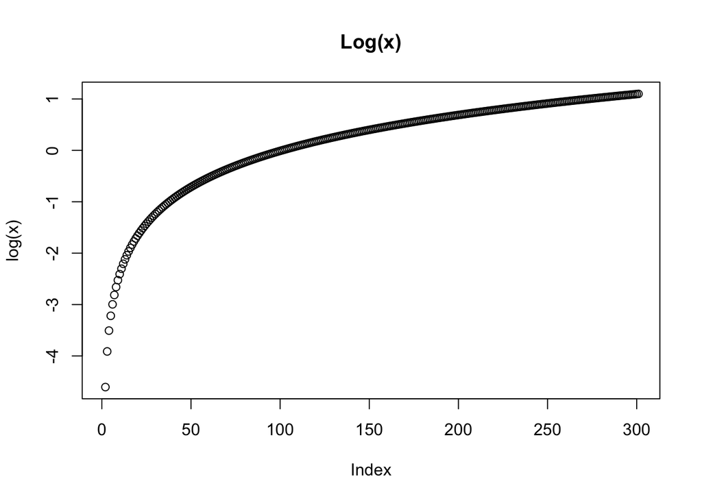

```r
x <- seq(0,3,.01)
plot(log(x), main = "Log(x)")
```

b. $e^{-x}$

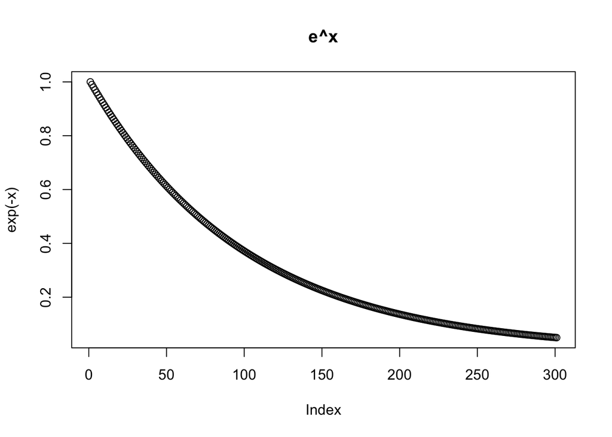

```r
x <- seq(0,3,.01)
plot(exp(-x), main = "e^x")
```

20. Make a barplot of the median number of frogs grouped by whether they have spots or not.

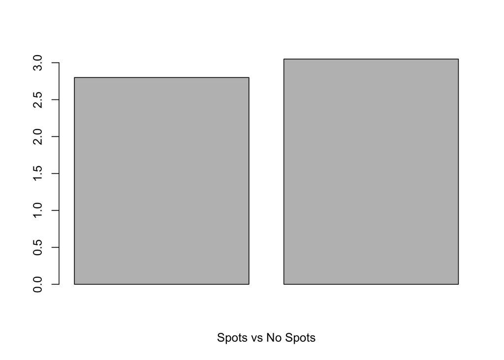

```r
yspots <- median(dat$frogs[which(dat$spots == TRUE)])
nspots <- median(dat$frogs[which(dat$spots == FALSE)])
barplot(c(yspots,nspots), xlab = "Spots vs No Spots")
```

21. Plot a histogram of blue frogs

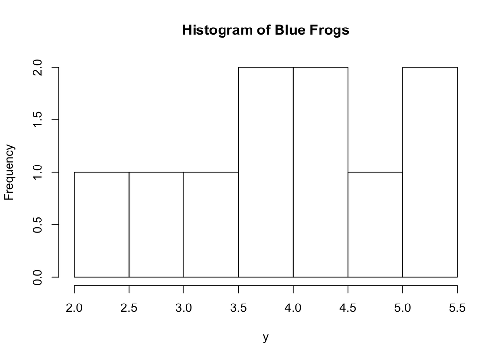

```r
y = dat$frogs[which(dat$color == "blue")]
hist(y, main = "Histogram of Blue Frogs")
```

22. Use apply to calculate the across-population standard deviations in the numbers of frogs and tadpoles

```r
sd(dat$frogs)
```

```
## [1] 1.275
```

```r
sd(dat$tadpoles)
```

```
## [1] 2.37
```

23. Using the frog data

1. ```
   Fit a linear model of tadpoles as a function of frogs for just the RED individuals and report the summary data of the fit.
   ```

```r
red <- dat[which(dat$color == "red"),]
fit <- lm(dat$tadpoles ~ dat$frogs, data=red)
summary(fit) # show results
```

```
##
## Call:
## lm(formula = dat$tadpoles ~ dat$frogs, data = red)
##
## Residuals:
##     Min      1Q  Median      3Q     Max
## -0.6096 -0.1830 -0.0067  0.2538  0.8504
##
## Coefficients:
##             Estimate Std. Error t value Pr(>|t|)
## (Intercept)   0.4545     0.2321    1.96    0.066 .
## dat$frogs     1.8358     0.0702   26.16    9e-16 ***
## ---
## Signif. codes:  0 '***' 0.001 '**' 0.01 '*' 0.05 '.' 0.1 ' ' 1
##
## Residual standard error: 0.39 on 18 degrees of freedom
## Multiple R-squared:  0.974,  Adjusted R-squared:  0.973
## F-statistic:  684 on 1 and 18 DF,  p-value: 8.97e-16
```

2. ```
   Make a scatter plot of this data that includes the regression line
   ```

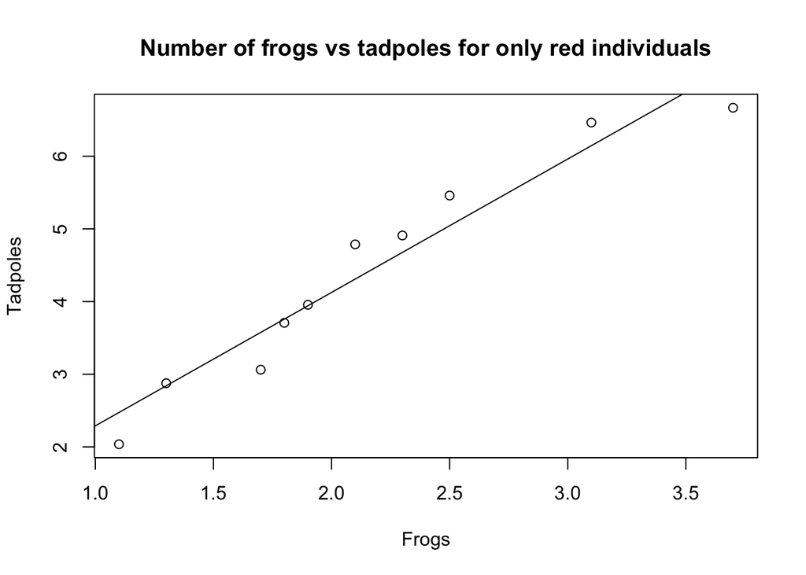

```r
plot(red$frogs,red$tadpoles, main = "Number of frogs vs tadpoles for only red individuals", xlab = "Frogs", ylab = "Tadpoles")
abline(fit)
```

c. Fit a series of linear models of tadpoles as a function of frogs, spots, color, and their interaction terms. Build up from a simple model to the most complex model that is supported by the available data (i.e. all terms should be significant). Also test the full model that includes all variables and interaction terms.

```r
fit <- aov(dat$tadpoles ~ dat$frogs, data=red)
summary(fit)
```

```
##             Df Sum Sq Mean Sq F value Pr(>F)
## dat$frogs    1  104.0   104.0     684  9e-16 ***
## Residuals   18    2.7     0.2
## ---
## Signif. codes:  0 '***' 0.001 '**' 0.01 '*' 0.05 '.' 0.1 ' ' 1
```

```r
fit <- aov(dat$tadpoles ~ dat$frogs + dat$spots, data=red)
summary(fit)
```

```
##             Df Sum Sq Mean Sq F value  Pr(>F)
## dat$frogs    1  104.0   104.0  676.28 3.9e-15 ***
## dat$spots    1    0.1     0.1    0.79    0.39
## Residuals   17    2.6     0.2
## ---
## Signif. codes:  0 '***' 0.001 '**' 0.01 '*' 0.05 '.' 0.1 ' ' 1
```

```r
fit <- aov(dat$tadpoles ~ dat$frogs + dat$spots + dat$color, data=red)
summary(fit)
```

```
##             Df Sum Sq Mean Sq F value  Pr(>F)
## dat$frogs    1  104.0   104.0  641.23 2.4e-14 ***
## dat$spots    1    0.1     0.1    0.75    0.40
## dat$color    1    0.0     0.0    0.12    0.73
## Residuals   16    2.6     0.2
## ---
## Signif. codes:  0 '***' 0.001 '**' 0.01 '*' 0.05 '.' 0.1 ' ' 1
```

```r
fit <- aov(dat$tadpoles ~ dat$frogs:dat$spots, data=red)
summary(fit)
```

```
##                     Df Sum Sq Mean Sq F value  Pr(>F)
## dat$frogs:dat$spots  2  104.3    52.1     358 1.3e-14 ***
## Residuals           17    2.5     0.1
## ---
## Signif. codes:  0 '***' 0.001 '**' 0.01 '*' 0.05 '.' 0.1 ' ' 1
```

```r
fit <- aov(dat$tadpoles ~ dat$frogs:dat$color, data=red)
summary(fit)
```

```
##                     Df Sum Sq Mean Sq F value Pr(>F)
## dat$frogs:dat$color  2  104.0    52.0     323  3e-14 ***
## Residuals           17    2.7     0.2
## ---
## Signif. codes:  0 '***' 0.001 '**' 0.01 '*' 0.05 '.' 0.1 ' ' 1
```

```r
fit <- aov(dat$tadpoles ~ dat$frogs:dat$spots +dat$frogs:dat$color, data=red)
summary(fit)
```

```
##                     Df Sum Sq Mean Sq F value  Pr(>F)
## dat$frogs:dat$spots  2  104.3    52.1  337.48 8.3e-14 ***
## dat$frogs:dat$color  1    0.0     0.0    0.01    0.94
## Residuals           16    2.5     0.2
## ---
## Signif. codes:  0 '***' 0.001 '**' 0.01 '*' 0.05 '.' 0.1 ' ' 1
```

```r
fit <- aov(dat$tadpoles ~ dat$frogs + dat$spots + dat$color + dat$frogs:dat$spots +dat$frogs:dat$color, data=red)
summary(fit)
```

```
##                     Df Sum Sq Mean Sq F value  Pr(>F)
## dat$frogs            1  104.0   104.0  625.78 5.1e-13 ***
## dat$spots            1    0.1     0.1    0.73    0.41
## dat$color            1    0.0     0.0    0.12    0.74
## dat$frogs:dat$spots  1    0.2     0.2    1.43    0.25
## dat$frogs:dat$color  1    0.0     0.0    0.18    0.68
## Residuals           14    2.3     0.2
## ---
## Signif. codes:  0 '***' 0.001 '**' 0.01 '*' 0.05 '.' 0.1 ' ' 1
```

24. Write an if statement that makes a scatter plot of x if all the values are positive, and plots a histogram otherwise.

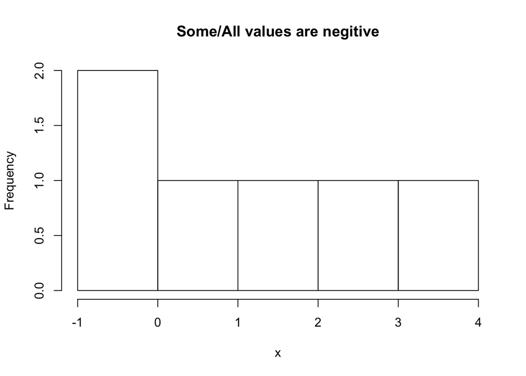

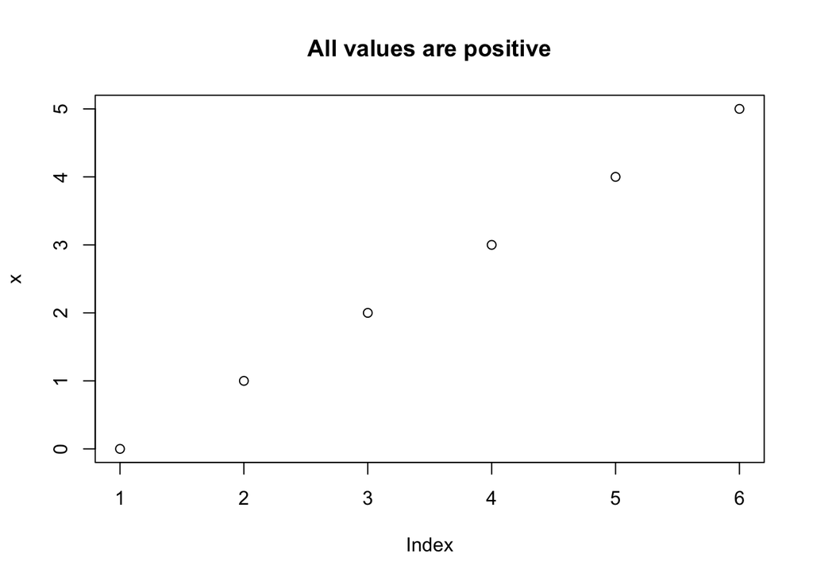

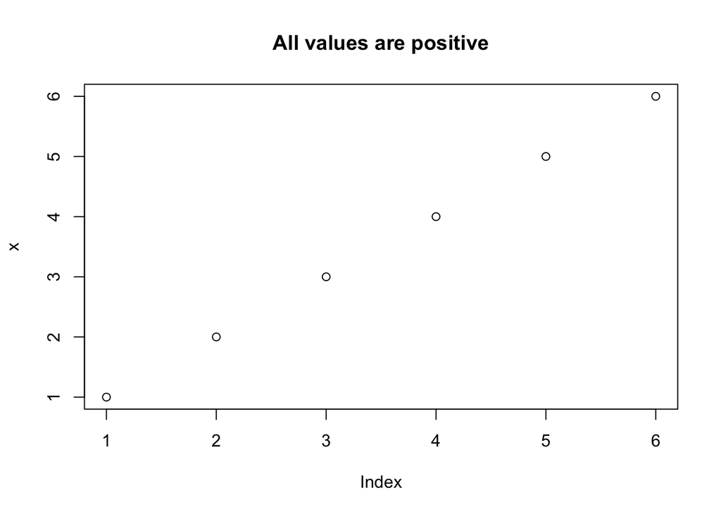

```r
x = c(-2,-1,0,1,2,3)
for(i in 0:2){
  x = x+1
  if (all(x>=0)){
    plot(x, main = "All values are positive")
    }else{hist(x, main = "Some/All values are negitive")}
  }
```

```r
frog.fcn <- function(dat){
  reg1 = lm(tadpoles ~ frogs,data=dat)
  plot(dat$frogs,dat$tadpoles,
     cex=1.5,           # increase the symbol size
     col=as.character(dat$color),   # change the symbol color by name
     pch=dat$spots+1,           # change the symbol (by number)
     cex.axis=1.3,          # increase the font size on the axis
     xlab="Frog Density",       # label the x axis
     ylab="Tadpole Density",        # label the y axis
     cex.lab=1.3,           # increase the axis label font size
     main="Frog Reproductive Effort", # title
     cex.main=2         # increase title font size
     )
  abline(reg1,col="green",        # add the regression line
     ,lwd=3)                # increase the line width
  legend("topleft",
       c("Red no spot","Blue no spot","Red spots","Blue Spots"),
       pch=c(1,1,2,2),
       col=c("red","blue","red","blue"),cex=1.3
       )
}
```

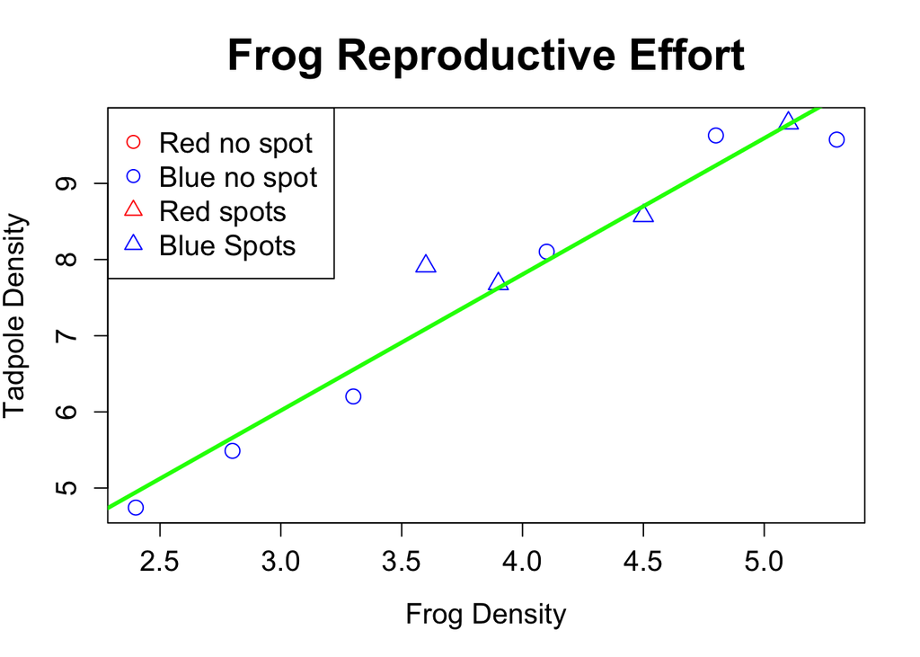

```r
rows <- which(dat$color == "blue")
blue.dat <- dat[rows,]
frog.fcn(blue.dat)
```

26. Starting with a vector x = 1:10, write a for loop that adds 5 to each value in the vector. Note that it is permissible to assign an element in a vector to itself (e.g. x[i] = x[i] + 5)

```r
x <- 1:10
for(i in 1:length(x)){
  x[i] = x[i] + 5
  print(x)
}
```

```
##  [1]  6  2  3  4  5  6  7  8  9 10
##  [1]  6  7  3  4  5  6  7  8  9 10
##  [1]  6  7  8  4  5  6  7  8  9 10
##  [1]  6  7  8  9  5  6  7  8  9 10
##  [1]  6  7  8  9 10  6  7  8  9 10
##  [1]  6  7  8  9 10 11  7  8  9 10
##  [1]  6  7  8  9 10 11 12  8  9 10
##  [1]  6  7  8  9 10 11 12 13  9 10
##  [1]  6  7  8  9 10 11 12 13 14 10
##  [1]  6  7  8  9 10 11 12 13 14 15
```

27. Modify the logistic growth code to simulate discrete-time exponential growth and plot the output.

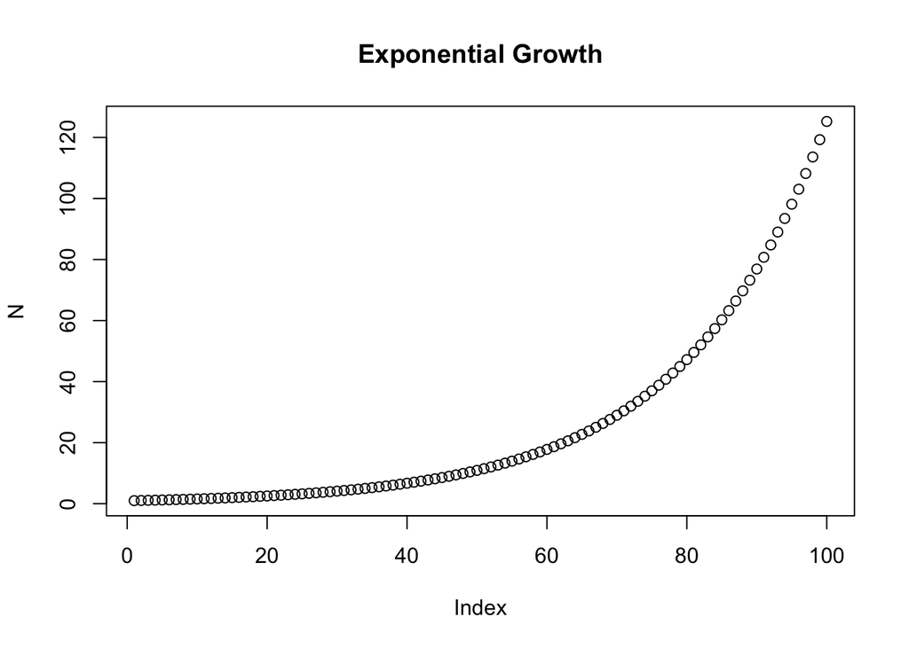

```r
NT = 100        ## number of time steps
N0 = 1              ## initial population size
r = 0.05                ## population growth rate
N = rep(N0,NT)
for(t in 2:NT){
    N[t] = N[t-1]*(1+r)   ## discrete exponential growth
}
plot(N, main = "Exponential Growth")
```